# INFO370 PS5

*Name*: Bridget Leonard \ *Collaborators*: 1) Saimanasvi Charugundla

```python
import numpy as np
import matplotlib.pyplot as plt
import pandas as pd
import seaborn as sns
import statsmodels.formula.api as smf
```

# Q1.Who will win the elections?

### 1.1

```python
election = pd.read_csv("../data/us-elections_2000-2020.csv.bz2", sep="\t")
election.shape
```

```
(37390, 24)
```

```python
election.head()
```

|  | FIPS | year | state | state2 | county | office | candidate | party | candidatevotes | totalvotes | ... | EDU600209D | POP010210D | POP220210D | POP250210D | POP320210D | POP400210D | PST110209D | BIRTHS2020 | DEATHS2020 | region |
| --- | --- | --- | --- | --- | --- | --- | --- | --- | --- | --- | --- | --- | --- | --- | --- | --- | --- | --- | --- | --- | --- |
| 0 | 1001 | 2000 | Alabama | AL | Autauga | President | Al Gore | democrat | 4942.0 | 17208 | ... | 31469 | 54571 | 42855 | 9643 | 474 | 1310 | 7085 | 143.0 | 168.0 | south |
| 1 | 1001 | 2000 | Alabama | AL | Autauga | President | George W. Bush | republican | 11993.0 | 17208 | ... | 31469 | 54571 | 42855 | 9643 | 474 | 1310 | 7085 | 143.0 | 168.0 | south |
| 2 | 1001 | 2004 | Alabama | AL | Autauga | President | John Kerry | democrat | 4758.0 | 20081 | ... | 31469 | 54571 | 42855 | 9643 | 474 | 1310 | 7085 | 143.0 | 168.0 | south |
| 3 | 1001 | 2004 | Alabama | AL | Autauga | President | George W. Bush | republican | 15196.0 | 20081 | ... | 31469 | 54571 | 42855 | 9643 | 474 | 1310 | 7085 | 143.0 | 168.0 | south |
| 4 | 1001 | 2008 | Alabama | AL | Autauga | President | Barack Obama | democrat | 6093.0 | 23641 | ... | 31469 | 54571 | 42855 | 9643 | 474 | 1310 | 7085 | 143.0 | 168.0 | south |

5 rows × 24 columns

```python
election.POP010210D
```

```
0        54571
1        54571
2        54571
3        54571
4        54571
         ...
37385     7208
37386     7208
37387     7208
37388     7208
37389     7208
Name: POP010210D, Length: 37390, dtype: int64
```

### 1.2

```python
x = list(range(6264, 6272))
x
```

```
[6264, 6265, 6266, 6267, 6268, 6269, 6270, 6271]
```

```python
election[["FIPS", "county", "year", "income"]].loc[x]
```

|  | FIPS | county | year | income |
| --- | --- | --- | --- | --- |
| 6264 | 15007 | Kauai | 2016 | 44958.0 |
| 6265 | 15007 | Kauai | 2016 | 44958.0 |
| 6266 | 15007 | Kauai County | 2020 | NaN |
| 6267 | 15007 | Kauai County | 2020 | NaN |
| 6268 | 15009 | Maui | 2000 | NaN |
| 6269 | 15009 | Maui | 2000 | NaN |
| 6270 | 15009 | Maui | 2004 | NaN |
| 6271 | 15009 | Maui | 2004 | NaN |

### 1.3

(a) For Kauai County and Maui, it'd expect the income to be pretty similar to the income of Kauai. A quick search on google states that Kauai County has a personal income of 35,000 and Maui currently has a personal income of 39,000.

(b) Since the FIPS are close, we'd assume that personal incomes would be fairly similar to each other since the counties are near each other.

(c) I would sort the data by grouping by FIPS then by year using sort_values and then use .fillna to fill the missing values with the closest year.

### 1.4

```python
election["fips2"] = election["FIPS"]
```

```python
election = election.sort_values(['fips2', 'year'])
```

```python
election = election.groupby('fips2').fillna(method="ffill")
```

### 1.5

```python
election[["FIPS", "county", "year", "income"]].loc[x]
```

|  | FIPS | county | year | income |
| --- | --- | --- | --- | --- |
| 6264 | 15007 | Kauai | 2016 | 44958.0 |
| 6265 | 15007 | Kauai | 2016 | 44958.0 |
| 6266 | 15007 | Kauai County | 2020 | 44958.0 |
| 6267 | 15007 | Kauai County | 2020 | 44958.0 |
| 6268 | 15009 | Maui | 2000 | NaN |
| 6269 | 15009 | Maui | 2000 | NaN |
| 6270 | 15009 | Maui | 2004 | NaN |
| 6271 | 15009 | Maui | 2004 | NaN |

Yes values are filled in by the year closest to them. This only applies to FIPS where there is an earlier existing value (based on year) to fill in the missing value.

### 1.6

```python
elec2020 = election[election.year == 2020].copy()
elec2020.shape
```

```
(6222, 24)
```

```python
elec2020.head()
```

|  | FIPS | year | state | state2 | county | office | candidate | party | candidatevotes | totalvotes | ... | EDU600209D | POP010210D | POP220210D | POP250210D | POP320210D | POP400210D | PST110209D | BIRTHS2020 | DEATHS2020 | region |
| --- | --- | --- | --- | --- | --- | --- | --- | --- | --- | --- | --- | --- | --- | --- | --- | --- | --- | --- | --- | --- | --- |
| 10 | 1001 | 2020 | Alabama | AL | Autauga County | President | Donald Trump | republican | 19838.0 | 27770 | ... | 31469 | 54571 | 42855 | 9643 | 474 | 1310 | 7085 | 143.0 | 168.0 | south |
| 11 | 1001 | 2020 | Alabama | AL | Autauga County | President | Joshep Biden | democrat | 7503.0 | 27770 | ... | 31469 | 54571 | 42855 | 9643 | 474 | 1310 | 7085 | 143.0 | 168.0 | south |
| 22 | 1003 | 2020 | Alabama | AL | Baldwin County | President | Donald Trump | republican | 83544.0 | 109679 | ... | 118585 | 182265 | 156153 | 17105 | 1348 | 7992 | 39463 | 527.0 | 661.0 | south |
| 23 | 1003 | 2020 | Alabama | AL | Baldwin County | President | Joshep Biden | democrat | 24578.0 | 109679 | ... | 118585 | 182265 | 156153 | 17105 | 1348 | 7992 | 39463 | 527.0 | 661.0 | south |
| 34 | 1005 | 2020 | Alabama | AL | Barbour County | President | Donald Trump | republican | 5622.0 | 10518 | ... | 19791 | 27457 | 13180 | 12875 | 107 | 1387 | 699 | 64.0 | 109.0 | south |

5 rows × 24 columns

```python
rep2020 = elec2020[elec2020.party == "republican"].sort_values("FIPS")
rep2020 = rep2020["candidatevotes"].reset_index()
rep2020
```

|  | index | candidatevotes |
| --- | --- | --- |
| 0 | 10 | 19838.0 |
| 1 | 22 | 83544.0 |
| 2 | 34 | 5622.0 |
| 3 | 46 | 7525.0 |
| 4 | 58 | 24711.0 |
| ... | ... | ... |
| 3106 | 37340 | 12229.0 |
| 3107 | 37352 | 4341.0 |
| 3108 | 37364 | 7496.0 |
| 3109 | 37376 | 3245.0 |
| 3110 | 37388 | 3107.0 |

3111 rows × 2 columns

```python
dem2020 = elec2020[elec2020.party == "democrat"].sort_values("FIPS")
dem2020 = dem2020["candidatevotes"].reset_index()
dem2020
```

|  | index | candidatevotes |
| --- | --- | --- |
| 0 | 11 | 7503.0 |
| 1 | 23 | 24578.0 |
| 2 | 35 | 4816.0 |
| 3 | 47 | 1986.0 |
| 4 | 59 | 2640.0 |
| ... | ... | ... |
| 3106 | 37341 | 3823.0 |
| 3107 | 37353 | 9848.0 |
| 3108 | 37365 | 1591.0 |
| 3109 | 37377 | 651.0 |
| 3110 | 37389 | 360.0 |

3111 rows × 2 columns

```python
elec2020["demWin"] = 0
elec2020.shape
```

```
(6222, 25)
```

```python
elec2020.head()
```

|  | FIPS | year | state | state2 | county | office | candidate | party | candidatevotes | totalvotes | ... | POP010210D | POP220210D | POP250210D | POP320210D | POP400210D | PST110209D | BIRTHS2020 | DEATHS2020 | region | demWin |
| --- | --- | --- | --- | --- | --- | --- | --- | --- | --- | --- | --- | --- | --- | --- | --- | --- | --- | --- | --- | --- | --- |
| 10 | 1001 | 2020 | Alabama | AL | Autauga County | President | Donald Trump | republican | 19838.0 | 27770 | ... | 54571 | 42855 | 9643 | 474 | 1310 | 7085 | 143.0 | 168.0 | south | 0 |
| 11 | 1001 | 2020 | Alabama | AL | Autauga County | President | Joshep Biden | democrat | 7503.0 | 27770 | ... | 54571 | 42855 | 9643 | 474 | 1310 | 7085 | 143.0 | 168.0 | south | 0 |
| 22 | 1003 | 2020 | Alabama | AL | Baldwin County | President | Donald Trump | republican | 83544.0 | 109679 | ... | 182265 | 156153 | 17105 | 1348 | 7992 | 39463 | 527.0 | 661.0 | south | 0 |
| 23 | 1003 | 2020 | Alabama | AL | Baldwin County | President | Joshep Biden | democrat | 24578.0 | 109679 | ... | 182265 | 156153 | 17105 | 1348 | 7992 | 39463 | 527.0 | 661.0 | south | 0 |
| 34 | 1005 | 2020 | Alabama | AL | Barbour County | President | Donald Trump | republican | 5622.0 | 10518 | ... | 27457 | 13180 | 12875 | 107 | 1387 | 699 | 64.0 | 109.0 | south | 0 |

5 rows × 25 columns

```python
for i in range(len(dem2020) - 1):
    dem = dem2020["candidatevotes"].iloc[i]
    rep = rep2020["candidatevotes"].iloc[i]
    demI = dem2020["index"].iloc[i]
    repI = rep2020["index"].iloc[i]
    if (dem > rep):
        elec2020.loc[demI, "demWin"] = 1
        elec2020.loc[repI, "demWin"] = 1
```

```python
elec2020.head(20)
```

|  | FIPS | year | state | state2 | county | office | candidate | party | candidatevotes | totalvotes | ... | POP010210D | POP220210D | POP250210D | POP320210D | POP400210D | PST110209D | BIRTHS2020 | DEATHS2020 | region | demWin |
| --- | --- | --- | --- | --- | --- | --- | --- | --- | --- | --- | --- | --- | --- | --- | --- | --- | --- | --- | --- | --- | --- |
| 10 | 1001 | 2020 | Alabama | AL | Autauga County | President | Donald Trump | republican | 19838.0 | 27770 | ... | 54571 | 42855 | 9643 | 474 | 1310 | 7085 | 143.0 | 168.0 | south | 0 |
| 11 | 1001 | 2020 | Alabama | AL | Autauga County | President | Joshep Biden | democrat | 7503.0 | 27770 | ... | 54571 | 42855 | 9643 | 474 | 1310 | 7085 | 143.0 | 168.0 | south | 0 |
| 22 | 1003 | 2020 | Alabama | AL | Baldwin County | President | Donald Trump | republican | 83544.0 | 109679 | ... | 182265 | 156153 | 17105 | 1348 | 7992 | 39463 | 527.0 | 661.0 | south | 0 |
| 23 | 1003 | 2020 | Alabama | AL | Baldwin County | President | Joshep Biden | democrat | 24578.0 | 109679 | ... | 182265 | 156153 | 17105 | 1348 | 7992 | 39463 | 527.0 | 661.0 | south | 0 |
| 34 | 1005 | 2020 | Alabama | AL | Barbour County | President | Donald Trump | republican | 5622.0 | 10518 | ... | 27457 | 13180 | 12875 | 107 | 1387 | 699 | 64.0 | 109.0 | south | 0 |
| 35 | 1005 | 2020 | Alabama | AL | Barbour County | President | Joshep Biden | democrat | 4816.0 | 10518 | ... | 27457 | 13180 | 12875 | 107 | 1387 | 699 | 64.0 | 109.0 | south | 0 |
| 46 | 1007 | 2020 | Alabama | AL | Bibb County | President | Donald Trump | republican | 7525.0 | 9595 | ... | 22915 | 17381 | 5047 | 22 | 406 | 1698 | 62.0 | 90.0 | south | 0 |
| 47 | 1007 | 2020 | Alabama | AL | Bibb County | President | Joshep Biden | democrat | 1986.0 | 9595 | ... | 22915 | 17381 | 5047 | 22 | 406 | 1698 | 62.0 | 90.0 | south | 0 |
| 58 | 1009 | 2020 | Alabama | AL | Blount County | President | Donald Trump | republican | 24711.0 | 27588 | ... | 57322 | 53068 | 761 | 117 | 4626 | 7323 | 152.0 | 220.0 | south | 0 |
| 59 | 1009 | 2020 | Alabama | AL | Blount County | President | Joshep Biden | democrat | 2640.0 | 27588 | ... | 57322 | 53068 | 761 | 117 | 4626 | 7323 | 152.0 | 220.0 | south | 0 |
| 70 | 1011 | 2020 | Alabama | AL | Bullock County | President | Donald Trump | republican | 1146.0 | 4613 | ... | 10914 | 2507 | 7666 | 20 | 777 | -641 | 33.0 | 37.0 | south | 1 |
| 71 | 1011 | 2020 | Alabama | AL | Bullock County | President | Joshep Biden | democrat | 3446.0 | 4613 | ... | 10914 | 2507 | 7666 | 20 | 777 | -641 | 33.0 | 37.0 | south | 1 |
| 82 | 1013 | 2020 | Alabama | AL | Butler County | President | Donald Trump | republican | 5458.0 | 9488 | ... | 20947 | 11399 | 9095 | 177 | 191 | -1435 | 40.0 | 58.0 | south | 0 |
| 83 | 1013 | 2020 | Alabama | AL | Butler County | President | Joshep Biden | democrat | 3965.0 | 9488 | ... | 20947 | 11399 | 9095 | 177 | 191 | -1435 | 40.0 | 58.0 | south | 0 |
| 94 | 1015 | 2020 | Alabama | AL | Calhoun County | President | Donald Trump | republican | 35101.0 | 50983 | ... | 118572 | 88840 | 24382 | 845 | 3893 | 1838 | 311.0 | 409.0 | south | 0 |
| 95 | 1015 | 2020 | Alabama | AL | Calhoun County | President | Joshep Biden | democrat | 15216.0 | 50983 | ... | 118572 | 88840 | 24382 | 845 | 3893 | 1838 | 311.0 | 409.0 | south | 0 |
| 106 | 1017 | 2020 | Alabama | AL | Chambers County | President | Donald Trump | republican | 8753.0 | 15284 | ... | 34215 | 20112 | 13257 | 168 | 536 | -2294 | 85.0 | 121.0 | south | 0 |
| 107 | 1017 | 2020 | Alabama | AL | Chambers County | President | Joshep Biden | democrat | 6365.0 | 15284 | ... | 34215 | 20112 | 13257 | 168 | 536 | -2294 | 85.0 | 121.0 | south | 0 |
| 118 | 1019 | 2020 | Alabama | AL | Cherokee County | President | Donald Trump | republican | 10583.0 | 12301 | ... | 25989 | 24081 | 1208 | 54 | 320 | 462 | 55.0 | 114.0 | south | 0 |
| 119 | 1019 | 2020 | Alabama | AL | Cherokee County | President | Joshep Biden | democrat | 1624.0 | 12301 | ... | 25989 | 24081 | 1208 | 54 | 320 | 462 | 55.0 | 114.0 | south | 0 |

20 rows × 25 columns

### 1.7

```python
elec2020["popDensity"] = elec2020["POP010210D"] / elec2020["LND010200D"]
```

```python
elec2020["collegeGrads"] = elec2020["EDU695209D"] / elec2020["EDU600209D"]
```

```python
elec2020.head(20)
```

|  | FIPS | year | state | state2 | county | office | candidate | party | candidatevotes | totalvotes | ... | POP250210D | POP320210D | POP400210D | PST110209D | BIRTHS2020 | DEATHS2020 | region | demWin | popDensity | collegeGrads |
| --- | --- | --- | --- | --- | --- | --- | --- | --- | --- | --- | --- | --- | --- | --- | --- | --- | --- | --- | --- | --- | --- |
| 10 | 1001 | 2020 | Alabama | AL | Autauga County | President | Donald Trump | republican | 19838.0 | 27770 | ... | 9643 | 474 | 1310 | 7085 | 143.0 | 168.0 | south | 0 | 90.282075 | 0.072611 |
| 11 | 1001 | 2020 | Alabama | AL | Autauga County | President | Joshep Biden | democrat | 7503.0 | 27770 | ... | 9643 | 474 | 1310 | 7085 | 143.0 | 168.0 | south | 0 | 90.282075 | 0.072611 |
| 22 | 1003 | 2020 | Alabama | AL | Baldwin County | President | Donald Trump | republican | 83544.0 | 109679 | ... | 17105 | 1348 | 7992 | 39463 | 527.0 | 661.0 | south | 0 | 89.921704 | 0.091538 |
| 23 | 1003 | 2020 | Alabama | AL | Baldwin County | President | Joshep Biden | democrat | 24578.0 | 109679 | ... | 17105 | 1348 | 7992 | 39463 | 527.0 | 661.0 | south | 0 | 89.921704 | 0.091538 |
| 34 | 1005 | 2020 | Alabama | AL | Barbour County | President | Donald Trump | republican | 5622.0 | 10518 | ... | 12875 | 107 | 1387 | 699 | 64.0 | 109.0 | south | 0 | 30.355327 | 0.052953 |
| 35 | 1005 | 2020 | Alabama | AL | Barbour County | President | Joshep Biden | democrat | 4816.0 | 10518 | ... | 12875 | 107 | 1387 | 699 | 64.0 | 109.0 | south | 0 | 30.355327 | 0.052953 |
| 46 | 1007 | 2020 | Alabama | AL | Bibb County | President | Donald Trump | republican | 7525.0 | 9595 | ... | 5047 | 22 | 406 | 1698 | 62.0 | 90.0 | south | 0 | 36.596078 | 0.032024 |
| 47 | 1007 | 2020 | Alabama | AL | Bibb County | President | Joshep Biden | democrat | 1986.0 | 9595 | ... | 5047 | 22 | 406 | 1698 | 62.0 | 90.0 | south | 0 | 36.596078 | 0.032024 |
| 58 | 1009 | 2020 | Alabama | AL | Blount County | President | Donald Trump | republican | 24711.0 | 27588 | ... | 761 | 117 | 4626 | 7323 | 152.0 | 220.0 | south | 0 | 88.106363 | 0.040575 |
| 59 | 1009 | 2020 | Alabama | AL | Blount County | President | Joshep Biden | democrat | 2640.0 | 27588 | ... | 761 | 117 | 4626 | 7323 | 152.0 | 220.0 | south | 0 | 88.106363 | 0.040575 |
| 70 | 1011 | 2020 | Alabama | AL | Bullock County | President | Donald Trump | republican | 1146.0 | 4613 | ... | 7666 | 20 | 777 | -641 | 33.0 | 37.0 | south | 1 | 17.432834 | 0.029937 |
| 71 | 1011 | 2020 | Alabama | AL | Bullock County | President | Joshep Biden | democrat | 3446.0 | 4613 | ... | 7666 | 20 | 777 | -641 | 33.0 | 37.0 | south | 1 | 17.432834 | 0.029937 |
| 82 | 1013 | 2020 | Alabama | AL | Butler County | President | Donald Trump | republican | 5458.0 | 9488 | ... | 9095 | 177 | 191 | -1435 | 40.0 | 58.0 | south | 0 | 26.926933 | 0.027508 |
| 83 | 1013 | 2020 | Alabama | AL | Butler County | President | Joshep Biden | democrat | 3965.0 | 9488 | ... | 9095 | 177 | 191 | -1435 | 40.0 | 58.0 | south | 0 | 26.926933 | 0.027508 |
| 94 | 1015 | 2020 | Alabama | AL | Calhoun County | President | Donald Trump | republican | 35101.0 | 50983 | ... | 24382 | 845 | 3893 | 1838 | 311.0 | 409.0 | south | 0 | 193.643846 | 0.070912 |
| 95 | 1015 | 2020 | Alabama | AL | Calhoun County | President | Joshep Biden | democrat | 15216.0 | 50983 | ... | 24382 | 845 | 3893 | 1838 | 311.0 | 409.0 | south | 0 | 193.643846 | 0.070912 |
| 106 | 1017 | 2020 | Alabama | AL | Chambers County | President | Donald Trump | republican | 8753.0 | 15284 | ... | 13257 | 168 | 536 | -2294 | 85.0 | 121.0 | south | 0 | 56.730945 | 0.031212 |
| 107 | 1017 | 2020 | Alabama | AL | Chambers County | President | Joshep Biden | democrat | 6365.0 | 15284 | ... | 13257 | 168 | 536 | -2294 | 85.0 | 121.0 | south | 0 | 56.730945 | 0.031212 |
| 118 | 1019 | 2020 | Alabama | AL | Cherokee County | President | Donald Trump | republican | 10583.0 | 12301 | ... | 1208 | 54 | 320 | 462 | 55.0 | 114.0 | south | 0 | 43.318610 | 0.038184 |
| 119 | 1019 | 2020 | Alabama | AL | Cherokee County | President | Joshep Biden | democrat | 1624.0 | 12301 | ... | 1208 | 54 | 320 | 462 | 55.0 | 114.0 | south | 0 | 43.318610 | 0.038184 |

20 rows × 27 columns

### 1.8

```python
elec2020["birthrate"] = (elec2020["BIRTHS2020"]*4) / (elec2020["POP010210D"]/1000)
```

```python
elec2020["deathrate"] = (elec2020["DEATHS2020"]*4) / (elec2020["POP010210D"]/1000)
```

```python
elec2020.head(20)
```

|  | FIPS | year | state | state2 | county | office | candidate | party | candidatevotes | totalvotes | ... | POP400210D | PST110209D | BIRTHS2020 | DEATHS2020 | region | demWin | popDensity | collegeGrads | birthrate | deathrate |
| --- | --- | --- | --- | --- | --- | --- | --- | --- | --- | --- | --- | --- | --- | --- | --- | --- | --- | --- | --- | --- | --- |
| 10 | 1001 | 2020 | Alabama | AL | Autauga County | President | Donald Trump | republican | 19838.0 | 27770 | ... | 1310 | 7085 | 143.0 | 168.0 | south | 0 | 90.282075 | 0.072611 | 10.481758 | 12.314233 |
| 11 | 1001 | 2020 | Alabama | AL | Autauga County | President | Joshep Biden | democrat | 7503.0 | 27770 | ... | 1310 | 7085 | 143.0 | 168.0 | south | 0 | 90.282075 | 0.072611 | 10.481758 | 12.314233 |
| 22 | 1003 | 2020 | Alabama | AL | Baldwin County | President | Donald Trump | republican | 83544.0 | 109679 | ... | 7992 | 39463 | 527.0 | 661.0 | south | 0 | 89.921704 | 0.091538 | 11.565578 | 14.506351 |
| 23 | 1003 | 2020 | Alabama | AL | Baldwin County | President | Joshep Biden | democrat | 24578.0 | 109679 | ... | 7992 | 39463 | 527.0 | 661.0 | south | 0 | 89.921704 | 0.091538 | 11.565578 | 14.506351 |
| 34 | 1005 | 2020 | Alabama | AL | Barbour County | President | Donald Trump | republican | 5622.0 | 10518 | ... | 1387 | 699 | 64.0 | 109.0 | south | 0 | 30.355327 | 0.052953 | 9.323670 | 15.879375 |
| 35 | 1005 | 2020 | Alabama | AL | Barbour County | President | Joshep Biden | democrat | 4816.0 | 10518 | ... | 1387 | 699 | 64.0 | 109.0 | south | 0 | 30.355327 | 0.052953 | 9.323670 | 15.879375 |
| 46 | 1007 | 2020 | Alabama | AL | Bibb County | President | Donald Trump | republican | 7525.0 | 9595 | ... | 406 | 1698 | 62.0 | 90.0 | south | 0 | 36.596078 | 0.032024 | 10.822605 | 15.710233 |
| 47 | 1007 | 2020 | Alabama | AL | Bibb County | President | Joshep Biden | democrat | 1986.0 | 9595 | ... | 406 | 1698 | 62.0 | 90.0 | south | 0 | 36.596078 | 0.032024 | 10.822605 | 15.710233 |
| 58 | 1009 | 2020 | Alabama | AL | Blount County | President | Donald Trump | republican | 24711.0 | 27588 | ... | 4626 | 7323 | 152.0 | 220.0 | south | 0 | 88.106363 | 0.040575 | 10.606748 | 15.351872 |
| 59 | 1009 | 2020 | Alabama | AL | Blount County | President | Joshep Biden | democrat | 2640.0 | 27588 | ... | 4626 | 7323 | 152.0 | 220.0 | south | 0 | 88.106363 | 0.040575 | 10.606748 | 15.351872 |
| 70 | 1011 | 2020 | Alabama | AL | Bullock County | President | Donald Trump | republican | 1146.0 | 4613 | ... | 777 | -641 | 33.0 | 37.0 | south | 1 | 17.432834 | 0.029937 | 12.094557 | 13.560564 |
| 71 | 1011 | 2020 | Alabama | AL | Bullock County | President | Joshep Biden | democrat | 3446.0 | 4613 | ... | 777 | -641 | 33.0 | 37.0 | south | 1 | 17.432834 | 0.029937 | 12.094557 | 13.560564 |
| 82 | 1013 | 2020 | Alabama | AL | Butler County | President | Donald Trump | republican | 5458.0 | 9488 | ... | 191 | -1435 | 40.0 | 58.0 | south | 0 | 26.926933 | 0.027508 | 7.638325 | 11.075572 |
| 83 | 1013 | 2020 | Alabama | AL | Butler County | President | Joshep Biden | democrat | 3965.0 | 9488 | ... | 191 | -1435 | 40.0 | 58.0 | south | 0 | 26.926933 | 0.027508 | 7.638325 | 11.075572 |
| 94 | 1015 | 2020 | Alabama | AL | Calhoun County | President | Donald Trump | republican | 35101.0 | 50983 | ... | 3893 | 1838 | 311.0 | 409.0 | south | 0 | 193.643846 | 0.070912 | 10.491516 | 13.797524 |
| 95 | 1015 | 2020 | Alabama | AL | Calhoun County | President | Joshep Biden | democrat | 15216.0 | 50983 | ... | 3893 | 1838 | 311.0 | 409.0 | south | 0 | 193.643846 | 0.070912 | 10.491516 | 13.797524 |
| 106 | 1017 | 2020 | Alabama | AL | Chambers County | President | Donald Trump | republican | 8753.0 | 15284 | ... | 536 | -2294 | 85.0 | 121.0 | south | 0 | 56.730945 | 0.031212 | 9.937162 | 14.145842 |
| 107 | 1017 | 2020 | Alabama | AL | Chambers County | President | Joshep Biden | democrat | 6365.0 | 15284 | ... | 536 | -2294 | 85.0 | 121.0 | south | 0 | 56.730945 | 0.031212 | 9.937162 | 14.145842 |
| 118 | 1019 | 2020 | Alabama | AL | Cherokee County | President | Donald Trump | republican | 10583.0 | 12301 | ... | 320 | 462 | 55.0 | 114.0 | south | 0 | 43.318610 | 0.038184 | 8.465120 | 17.545885 |
| 119 | 1019 | 2020 | Alabama | AL | Cherokee County | President | Joshep Biden | democrat | 1624.0 | 12301 | ... | 320 | 462 | 55.0 | 114.0 | south | 0 | 43.318610 | 0.038184 | 8.465120 | 17.545885 |

20 rows × 29 columns

### 1.9

```python
# check population density
```

```python
elec2020.popDensity.min(), elec2020.popDensity.max()
```

```
(0.1211494422693359, inf)
```

```python
# college grads
```

```python
elec2020.collegeGrads.min(), elec2020.collegeGrads.max()
```

```
(0.0, 0.38463648834019204)
```

```python
# income
```

```python
elec2020.income.min(), elec2020.income.max()
```

```
(18183.0, 205843.0)
```

```python
# region
```

```python
elec2020.region.value_counts()
```

```
south        2844
midwest      2108
west          836
northeast     434
Name: region, dtype: int64
```

```python
# drop inf values in population density with NaN values
```

```python
elec2020.popDensity.replace([np.inf, -np.inf], np.nan, inplace=True)
```

```python
elec2020.popDensity.min(), elec2020.popDensity.max()
```

```
(0.1211494422693359, 46961.00088836245)
```

### 1.10

```python
elec2020.columns
```

```
Index(['FIPS', 'year', 'state', 'state2', 'county', 'office', 'candidate',
       'party', 'candidatevotes', 'totalvotes', 'income', 'population',
       'LND010200D', 'EDU695209D', 'EDU600209D', 'POP010210D', 'POP220210D',
       'POP250210D', 'POP320210D', 'POP400210D', 'PST110209D', 'BIRTHS2020',
       'DEATHS2020', 'region', 'demWin', 'popDensity', 'collegeGrads',
       'birthrate', 'deathrate'],
      dtype='object')
```

```python
m = smf.logit("demWin ~ popDensity + collegeGrads + income + region", data=elec2020).fit()
m.summary()
```

```
Optimization terminated successfully.
         Current function value: 0.304636
         Iterations 8
```

Logit Regression Results

| Dep. Variable: | demWin | No. Observations: | 6116 |
| --- | --- | --- | --- |
| Model: | Logit | Df Residuals: | 6109 |
| Method: | MLE | Df Model: | 6 |
| Date: | Sat, 18 Feb 2023 | Pseudo R-squ.: | 0.3241 |
| Time: | 19:14:26 | Log-Likelihood: | -1863.2 |
| converged: | True | LL-Null: | -2756.7 |
| Covariance Type: | nonrobust | LLR p-value: | 0.000 |

|  | coef | std err | z | P>\|z\| | [0.025 | 0.975] |
| --- | --- | --- | --- | --- | --- | --- |
| Intercept | -3.7207 | 0.205 | -18.174 | 0.000 | -4.122 | -3.319 |
| region[T.northeast] | 1.2687 | 0.156 | 8.129 | 0.000 | 0.963 | 1.575 |
| region[T.south] | 0.6286 | 0.117 | 5.396 | 0.000 | 0.400 | 0.857 |
| region[T.west] | 1.5301 | 0.132 | 11.554 | 0.000 | 1.271 | 1.790 |
| popDensity | 0.0026 | 0.000 | 13.458 | 0.000 | 0.002 | 0.003 |
| collegeGrads | 28.2060 | 1.568 | 17.992 | 0.000 | 25.133 | 31.279 |
| income | -2.649e-05 | 5.09e-06 | -5.208 | 0.000 | -3.65e-05 | -1.65e-05 |

### 1.11

Because the democrat candidate winning in each region is a binary variable: either wins or doesn't, we want to use logistic regression. This helps us capture the binary outcome so that we do not predict results that are somewhere in between winning and losing because those in actuality do not exist.

### 1.12

```python
elec2020["popDensity"] = (elec2020["POP010210D"]/1000) / elec2020["LND010200D"]
```

```python
elec2020.head()
```

|  | FIPS | year | state | state2 | county | office | candidate | party | candidatevotes | totalvotes | ... | POP400210D | PST110209D | BIRTHS2020 | DEATHS2020 | region | demWin | popDensity | collegeGrads | birthrate | deathrate |
| --- | --- | --- | --- | --- | --- | --- | --- | --- | --- | --- | --- | --- | --- | --- | --- | --- | --- | --- | --- | --- | --- |
| 10 | 1001 | 2020 | Alabama | AL | Autauga County | President | Donald Trump | republican | 19838.0 | 27770 | ... | 1310 | 7085 | 143.0 | 168.0 | south | 0 | 0.090282 | 0.072611 | 10.481758 | 12.314233 |
| 11 | 1001 | 2020 | Alabama | AL | Autauga County | President | Joshep Biden | democrat | 7503.0 | 27770 | ... | 1310 | 7085 | 143.0 | 168.0 | south | 0 | 0.090282 | 0.072611 | 10.481758 | 12.314233 |
| 22 | 1003 | 2020 | Alabama | AL | Baldwin County | President | Donald Trump | republican | 83544.0 | 109679 | ... | 7992 | 39463 | 527.0 | 661.0 | south | 0 | 0.089922 | 0.091538 | 11.565578 | 14.506351 |
| 23 | 1003 | 2020 | Alabama | AL | Baldwin County | President | Joshep Biden | democrat | 24578.0 | 109679 | ... | 7992 | 39463 | 527.0 | 661.0 | south | 0 | 0.089922 | 0.091538 | 11.565578 | 14.506351 |
| 34 | 1005 | 2020 | Alabama | AL | Barbour County | President | Donald Trump | republican | 5622.0 | 10518 | ... | 1387 | 699 | 64.0 | 109.0 | south | 0 | 0.030355 | 0.052953 | 9.323670 | 15.879375 |

5 rows × 29 columns

```python
m.get_margeff().summary()
```

Logit Marginal Effects

| Dep. Variable: | demWin |
| --- | --- |
| Method: | dydx |
| At: | overall |

|  | dy/dx | std err | z | P>\|z\| | [0.025 | 0.975] |
| --- | --- | --- | --- | --- | --- | --- |
| region[T.northeast] | 0.1132 | 0.014 | 8.169 | 0.000 | 0.086 | 0.140 |
| region[T.south] | 0.0561 | 0.010 | 5.392 | 0.000 | 0.036 | 0.076 |
| region[T.west] | 0.1365 | 0.012 | 11.643 | 0.000 | 0.114 | 0.160 |
| popDensity | 0.0002 | 1.68e-05 | 13.995 | 0.000 | 0.000 | 0.000 |
| collegeGrads | 2.5169 | 0.132 | 19.134 | 0.000 | 2.259 | 2.775 |
| income | -2.364e-06 | 4.53e-07 | -5.223 | 0.000 | -3.25e-06 | -1.48e-06 |

```python
# midwest is the reference
```

Counties in the Northeast are 11 percent points more likely to have a democrat win compared to Midwest counties, if population density, college graduations, and income are all the same.

Counties in the South are 6 percent points more likely to have a democrat win compared to Midwest counties, if population density, college graduations, and income are all the same.

Counties in the West are 14 percent points more likely to have a democrat win compared to Midwest counties, if population density, college graduations, and income are all the same.

# Q2.Model Airbnb Price

### 2.1

```python
airbnb = pd.read_csv("../data/airbnb-beijing-listings.csv.bz2", usecols=['price', 'bedrooms', 'room_type', 'accommodates', 'bathrooms'])
airbnb.shape
```

```
(38814, 5)
```

```python
airbnb.columns
```

```
Index(['room_type', 'accommodates', 'bathrooms', 'bedrooms', 'price'], dtype='object')
```

```python
airbnb.head()
```

|  | room_type | accommodates | bathrooms | bedrooms | price |
| --- | --- | --- | --- | --- | --- |
| 0 | Entire home/apt | 9 | 2.0 | 3.0 | $831.00 |
| 1 | Private room | 2 | 1.0 | 1.0 | $1,197.00 |
| 2 | Entire home/apt | 2 | 1.0 | 1.0 | $598.00 |
| 3 | Entire home/apt | 2 | 1.0 | 1.0 | $598.00 |
| 4 | Entire home/apt | 2 | 1.0 | 1.0 | $598.00 |

### 2.2

```python
airbnb["price"] = airbnb["price"].replace('[$,]', '', regex=True).astype(float)
```

```python
airbnb.head()
```

|  | room_type | accommodates | bathrooms | bedrooms | price |
| --- | --- | --- | --- | --- | --- |
| 0 | Entire home/apt | 9 | 2.0 | 3.0 | 831.0 |
| 1 | Private room | 2 | 1.0 | 1.0 | 1197.0 |
| 2 | Entire home/apt | 2 | 1.0 | 1.0 | 598.0 |
| 3 | Entire home/apt | 2 | 1.0 | 1.0 | 598.0 |
| 4 | Entire home/apt | 2 | 1.0 | 1.0 | 598.0 |

```python
airbnb.isna().sum()
```

```
room_type         0
accommodates      0
bathrooms         7
bedrooms        114
price             0
dtype: int64
```

```python
airbnb = airbnb.dropna()
```

```python
airbnb.isna().sum()
```

```
room_type       0
accommodates    0
bathrooms       0
bedrooms        0
price           0
dtype: int64
```

```python
airbnb.room_type.value_counts()
```

```
Entire home/apt    23840
Private room       13053
Shared room         1802
Name: room_type, dtype: int64
```

```python
airbnb.accommodates.min(), airbnb.accommodates.max()
```

```
(1, 34)
```

```python
airbnb.bathrooms.min(), airbnb.bathrooms.max()
```

```
(0.0, 101.5)
```

```python
airbnb.bedrooms.min(), airbnb.bedrooms.max()
```

```
(0.0, 50.0)
```

```python
airbnb.price.min(), airbnb.price.max()
```

```
(0.0, 71603.0)
```

```python
airbnb[airbnb.price == 0]
```

|  | room_type | accommodates | bathrooms | bedrooms | price |
| --- | --- | --- | --- | --- | --- |
| 9000 | Entire home/apt | 1 | 1.0 | 0.0 | 0.0 |
| 30462 | Private room | 1 | 1.0 | 1.0 | 0.0 |
| 33005 | Private room | 1 | 2.0 | 1.0 | 0.0 |
| 34731 | Entire home/apt | 2 | 1.0 | 1.0 | 0.0 |
| 35040 | Entire home/apt | 2 | 1.5 | 1.0 | 0.0 |
| 36292 | Shared room | 2 | 1.0 | 1.0 | 0.0 |
| 36297 | Shared room | 2 | 1.0 | 1.0 | 0.0 |
| 36298 | Shared room | 2 | 1.0 | 1.0 | 0.0 |
| 36533 | Entire home/apt | 4 | 1.0 | 2.0 | 0.0 |

```python
# remove airbnb listings with a price of $0 since that is an invalid value
```

```python
airbnb = airbnb[airbnb['price'] != 0].copy()
```

### 2.3

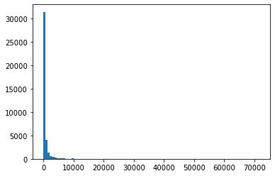

```python
_ = plt.hist(airbnb.price, bins = 100)
```

The distribution of price is not normal, it is very right-skewed. It suggests that a log transformation would useful. Price is typically a log-distributed value because it has a defined lower bound ($0) but no defined upper bound.

### 2.4

```python
airbnb["bedrooms"] = pd.cut(airbnb.bedrooms,
                      bins = [0, 1, 2, 3, 4, np.inf],
                      labels = ["0", "1", "2", "3", "4 or more"],
                      right=False)
```

```python
airbnb.head(20)
```

|  | room_type | accommodates | bathrooms | bedrooms | price |
| --- | --- | --- | --- | --- | --- |
| 0 | Entire home/apt | 9 | 2.0 | 3 | 831.0 |
| 1 | Private room | 2 | 1.0 | 1 | 1197.0 |
| 2 | Entire home/apt | 2 | 1.0 | 1 | 598.0 |
| 3 | Entire home/apt | 2 | 1.0 | 1 | 598.0 |
| 4 | Entire home/apt | 2 | 1.0 | 1 | 598.0 |
| 5 | Entire home/apt | 3 | 1.0 | 1 | 408.0 |
| 6 | Entire home/apt | 2 | 1.0 | 1 | 563.0 |
| 7 | Entire home/apt | 4 | 1.0 | 1 | 704.0 |
| 8 | Entire home/apt | 2 | 1.0 | 1 | 401.0 |
| 9 | Entire home/apt | 4 | 2.0 | 2 | 669.0 |
| 10 | Entire home/apt | 3 | 1.0 | 1 | 415.0 |
| 11 | Entire home/apt | 2 | 0.0 | 1 | 549.0 |
| 12 | Entire home/apt | 2 | 1.0 | 1 | 436.0 |
| 13 | Entire home/apt | 6 | 1.0 | 2 | 950.0 |
| 14 | Entire home/apt | 3 | 1.0 | 1 | 436.0 |
| 15 | Entire home/apt | 2 | 1.0 | 1 | 479.0 |
| 16 | Entire home/apt | 2 | 1.0 | 1 | 563.0 |
| 17 | Entire home/apt | 2 | 1.0 | 1 | 415.0 |
| 18 | Private room | 16 | 6.0 | 4 or more | 8898.0 |
| 19 | Private room | 3 | 1.0 | 1 | 415.0 |

### 2.5

```python
m = smf.ols("price ~ bedrooms", data=airbnb).fit()
m.summary()
```

OLS Regression Results

| Dep. Variable: | price | R-squared: | 0.102 |
| --- | --- | --- | --- |
| Model: | OLS | Adj. R-squared: | 0.101 |
| Method: | Least Squares | F-statistic: | 1093. |
| Date: | Sat, 18 Feb 2023 | Prob (F-statistic): | 0.00 |
| Time: | 19:25:49 | Log-Likelihood: | -3.4133e+05 |
| No. Observations: | 38686 | AIC: | 6.827e+05 |
| Df Residuals: | 38681 | BIC: | 6.827e+05 |
| Df Model: | 4 |  |  |
| Covariance Type: | nonrobust |  |  |

|  | coef | std err | t | P>\|t\| | [0.025 | 0.975] |
| --- | --- | --- | --- | --- | --- | --- |
| Intercept | 448.8851 | 107.166 | 4.189 | 0.000 | 238.837 | 658.933 |
| bedrooms[T.1] | -11.6223 | 107.655 | -0.108 | 0.914 | -222.628 | 199.384 |
| bedrooms[T.2] | 295.9590 | 108.801 | 2.720 | 0.007 | 82.705 | 509.213 |
| bedrooms[T.3] | 746.0202 | 111.966 | 6.663 | 0.000 | 526.565 | 965.476 |
| bedrooms[T.4 or more] | 2167.8388 | 111.995 | 19.357 | 0.000 | 1948.326 | 2387.352 |

| Omnibus: | 95843.461 | Durbin-Watson: | 1.973 |
| --- | --- | --- | --- |
| Prob(Omnibus): | 0.000 | Jarque-Bera (JB): | 1539629661.103 |
| Skew: | 26.864 | Prob(JB): | 0.00 |
| Kurtosis: | 978.842 | Cond. No. | 35.8 |

Notes:  
[1] Standard Errors assume that the covariance matrix of the errors is correctly specified.

A 0 bedroom listing on airbnb costs $448.89 on average.

A one bedroom listing on airbnb costs $11.62 less than a 0 bedroom listing on average.

A two bedroom listing on airbnb costs $295.96 more than a 0 bedroom listing on average.

A three bedroom listing on airbnb costs $746.02 more on average than a 0 bedroom listing.

A four or more bedroom listing on airbb costs $2167.84 more than a 0 bedroom listing on average.

Our linear model of using number of bedrooms to explain listing price explains 0.102 of the variance in the data. In this way, it is not a very predictive model, since most of the variance is left unexplained.

### 2.6

```python
m = smf.ols("np.log(price) ~ bedrooms", data=airbnb).fit()
m.summary()
```

OLS Regression Results

| Dep. Variable: | np.log(price) | R-squared: | 0.321 |
| --- | --- | --- | --- |
| Model: | OLS | Adj. R-squared: | 0.320 |
| Method: | Least Squares | F-statistic: | 4562. |
| Date: | Sat, 18 Feb 2023 | Prob (F-statistic): | 0.00 |
| Time: | 19:26:56 | Log-Likelihood: | -40076. |
| No. Observations: | 38686 | AIC: | 8.016e+04 |
| Df Residuals: | 38681 | BIC: | 8.020e+04 |
| Df Model: | 4 |  |  |
| Covariance Type: | nonrobust |  |  |

|  | coef | std err | t | P>\|t\| | [0.025 | 0.975] |
| --- | --- | --- | --- | --- | --- | --- |
| Intercept | 5.8117 | 0.044 | 130.662 | 0.000 | 5.724 | 5.899 |
| bedrooms[T.1] | -0.0323 | 0.045 | -0.724 | 0.469 | -0.120 | 0.055 |
| bedrooms[T.2] | 0.5306 | 0.045 | 11.749 | 0.000 | 0.442 | 0.619 |
| bedrooms[T.3] | 0.9396 | 0.046 | 20.219 | 0.000 | 0.848 | 1.031 |
| bedrooms[T.4 or more] | 1.5931 | 0.046 | 34.272 | 0.000 | 1.502 | 1.684 |

| Omnibus: | 3876.704 | Durbin-Watson: | 1.780 |
| --- | --- | --- | --- |
| Prob(Omnibus): | 0.000 | Jarque-Bera (JB): | 16891.857 |
| Skew: | 0.418 | Prob(JB): | 0.00 |
| Kurtosis: | 6.128 | Cond. No. | 35.8 |

Notes:  
[1] Standard Errors assume that the covariance matrix of the errors is correctly specified.

This model is better in terms of R squared. Our R squared value is no 0.32 compared to the original 0.102. This means we gain predictive power when we use number of bedrooms to explain the log price instead of just price.

### 2.7

```python
# recode accommodates
```

```python
airbnb["accommodates"] = pd.cut(airbnb.accommodates,
                      bins = [1, 2, 3, 4, np.inf],
                      labels = ["1", "2", "3", "4 or more"],
                      right=False)
```

```python
# recode bathrooms
```

```python
airbnb["bathrooms"] = pd.cut(airbnb.bathrooms,
                      bins = [0, 0.5, 1.5, 2.5, 3.5, np.inf],
                      labels = ["0", "1", "2", "3", "4 or more"],
                      right=False)
```

```python
airbnb.head(10)
```

|  | room_type | accommodates | bathrooms | bedrooms | price |
| --- | --- | --- | --- | --- | --- |
| 0 | Entire home/apt | 4 or more | 2 | 3 | 831.0 |
| 1 | Private room | 2 | 1 | 1 | 1197.0 |
| 2 | Entire home/apt | 2 | 1 | 1 | 598.0 |
| 3 | Entire home/apt | 2 | 1 | 1 | 598.0 |
| 4 | Entire home/apt | 2 | 1 | 1 | 598.0 |
| 5 | Entire home/apt | 3 | 1 | 1 | 408.0 |
| 6 | Entire home/apt | 2 | 1 | 1 | 563.0 |
| 7 | Entire home/apt | 4 or more | 1 | 1 | 704.0 |
| 8 | Entire home/apt | 2 | 1 | 1 | 401.0 |
| 9 | Entire home/apt | 4 or more | 2 | 2 | 669.0 |

```python
m = smf.ols("np.log(price) ~ bedrooms + room_type + accommodates + bathrooms", data=airbnb).fit()
m.summary()
```

OLS Regression Results

| Dep. Variable: | np.log(price) | R-squared: | 0.457 |
| --- | --- | --- | --- |
| Model: | OLS | Adj. R-squared: | 0.457 |
| Method: | Least Squares | F-statistic: | 2508. |
| Date: | Sat, 18 Feb 2023 | Prob (F-statistic): | 0.00 |
| Time: | 19:40:28 | Log-Likelihood: | -35723. |
| No. Observations: | 38686 | AIC: | 7.147e+04 |
| Df Residuals: | 38672 | BIC: | 7.159e+04 |
| Df Model: | 13 |  |  |
| Covariance Type: | nonrobust |  |  |

|  | coef | std err | t | P>\|t\| | [0.025 | 0.975] |
| --- | --- | --- | --- | --- | --- | --- |
| Intercept | 5.5786 | 0.062 | 90.138 | 0.000 | 5.457 | 5.700 |
| bedrooms[T.1] | 0.0559 | 0.040 | 1.398 | 0.162 | -0.022 | 0.134 |
| bedrooms[T.2] | 0.1911 | 0.041 | 4.665 | 0.000 | 0.111 | 0.271 |
| bedrooms[T.3] | 0.4997 | 0.042 | 11.804 | 0.000 | 0.417 | 0.583 |
| bedrooms[T.4 or more] | 0.8230 | 0.044 | 18.564 | 0.000 | 0.736 | 0.910 |
| room_type[T.Private room] | -0.3245 | 0.007 | -43.894 | 0.000 | -0.339 | -0.310 |
| room_type[T.Shared room] | -0.9438 | 0.017 | -56.006 | 0.000 | -0.977 | -0.911 |
| accommodates[T.2] | 0.3298 | 0.013 | 24.466 | 0.000 | 0.303 | 0.356 |
| accommodates[T.3] | 0.3916 | 0.017 | 23.531 | 0.000 | 0.359 | 0.424 |
| accommodates[T.4 or more] | 0.6060 | 0.015 | 39.168 | 0.000 | 0.576 | 0.636 |
| bathrooms[T.1] | 0.0035 | 0.047 | 0.075 | 0.940 | -0.088 | 0.095 |
| bathrooms[T.2] | 0.0392 | 0.047 | 0.832 | 0.405 | -0.053 | 0.132 |
| bathrooms[T.3] | 0.5144 | 0.051 | 10.179 | 0.000 | 0.415 | 0.613 |
| bathrooms[T.4 or more] | 0.7066 | 0.052 | 13.676 | 0.000 | 0.605 | 0.808 |

| Omnibus: | 9104.898 | Durbin-Watson: | 1.778 |
| --- | --- | --- | --- |
| Prob(Omnibus): | 0.000 | Jarque-Bera (JB): | 54912.477 |
| Skew: | 0.997 | Prob(JB): | 0.00 |
| Kurtosis: | 8.486 | Cond. No. | 57.0 |

Notes:  
[1] Standard Errors assume that the covariance matrix of the errors is correctly specified.

```python
# reference categories: bedrooms - 0; room_type - entire home/apt; accommodates - 1; bathrooms - 0
```

```python
# Intercept Interpretation
```

A 0 bedroom, 0 bathroom, entire home/apartment listing that accomodates one will on average have a log price of 5.58.

```python
# Bedrooms
```

As expected this model predicts that more bedrooms typically means a more expensive listing on average if all other factors remain the same. If room type, accommodation, and bathrooms are all the same, one bedrooms have a log price 0.06 more than a zero bedroom on average, two bedrooms have a log price 0.2 more than a zero bedroom on average, three bedrooms have a log price 0.5 more than a zero bedroom on average, and four or more bedrooms have a log price 0.82 more than a zero bedroom on average. Interesting, while all other values are significant, the effect of a one bedroom is not significant. This means we fail to reject the null hypothesis that one bedrooms and zero bedrooms are different in listing price if all factors are the same.

```python
# Room Type
```

As expected this model predicts that the less privacy in room types (more shared space) typically means a less expensive listing on average if all other factors remain the same. If bedrooms, accommodation, and bathrooms are all the same, private rooms have a log price of 0.32 less than a entire unit on average, and shared rooms have a log price of 0.94 less than a entire unit on average.

```python
# Accommodates
```

As expected this model predicts that more people a listing can accommodate typically means a more expensive listing on average if all other factors remain the same. If bedrooms, room type, and bathrooms are all the same, two accommodation listings have a log price of 0.33 more than a single accommodation listings on average, three accommodation listings have a log price of 0.39 more than a single accommodation listings on average, and four or more accommodation listings have a log price of 0.61 more than a single accommodation listings on average.

```python
# Bathrooms
```

As expected this model predicts that more bathrooms typically means a more expensive listing on average if all other factors remain the same. If bedrooms, room type, and accommodation are all the same, single bathroom listings have a log price of .004 more than a zero bathroom listings on average, two bathroom listings have a log price of 0.04 more than a zero bathroom listings on average, three bathroom listings have a log price of 0.51 more than a zero bathroom listings on average, and four or more bathroom listings have a log price of 0.71 more than a zero bathroom listings on average. Neither the one bathroom nor two bathroom effect is significant, meaning we fail to reject the null hypothesis that single bathroom and zero bathroom listings are different in listing price if all factors are the same and we fail to reject the null hypothesis that double bathroom and zero bathroom listings are different in listing price if all factors are the same.

# Time Spent

I spent about 9 hours on this problem set.